# 最终报告

常佳琪

2020/6/18

## 4.3 互相关分析

由前面的理论可知，如果直接用两列数据做互相关分析，会因为存在公共趋势而导致结果有偏，故需要先对数据进行预白化。预白化的第一步是用X变量拟合一个ARIMA模型，并计算模型残差；第二步是用X的ARIMA模型对y变量进行过滤。由于本次研究中西藏和青海的疫情数量较小，故仅研究除去西藏和青海的省份的迁徙与疫情的互相关分析。结果见下图：

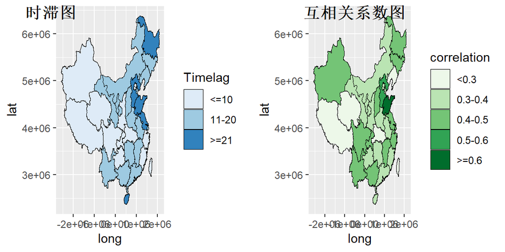

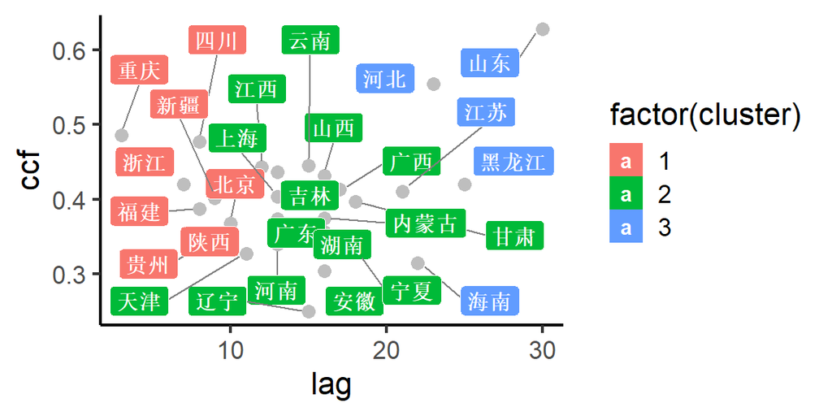

## 4.4 ARIMAX模型

建立ARIMAX模型通常分为四步：  
1、对数据进行处理，并进行平稳化检验；  
2、考察观测变量和输入变量的互相关关系以确定滞后回归项；  
3、建立ARIMAX模型，确定p,d,q的值；  
4、进行模型检验及预测。  
对三大集群的疫情数据进行ADF平稳性检验，发现在5%显著性水平下，全部通过检验。

| 类别 | Dickey-Fuller | p-value | 结果 |
| --- | --- | --- | --- |
| 第一集群 | -3.8212 | 0.0298 | 平稳 |
| 第二集群 | -4.6805 | <0.01 | 平稳 |
| 第三集群 | -3.6175 | 0.0453 | 平稳 |

考察三大集群经过平稳化后的迁移数据和疫情数据的互相关关系，发现分别滞后8阶、滞后16阶与滞后26阶最显著，这也与三大集群是按不同滞后阶数的汇总数据情况吻合。分别利用滞后8阶、滞后16阶与滞后26阶建立三个集群的ARIMAX模型,三个模型系数的P值在10%的显著性水平下通过检验。进行LB检验的结果发现，三个模型的残差均是独立和随机的序列，最终得到三个模型的信息见下表：

| 滞后阶数 | Model | RMSE | MAE | AIC | BIC | 百分比 |
| --- | --- | --- | --- | --- | --- | --- |
| 1-10 | (1,1,0) | 25.66 | 20.26 | 282.03 | 287.5 | 29% |
| 11-20 | (2,0,0) | 51.18 | 41.87 | 207.09 | 211.54 | 53% |
| 20以上 | (2,0,0) | 12.85 | 10.37 | 102 | 103.99 | 18% |

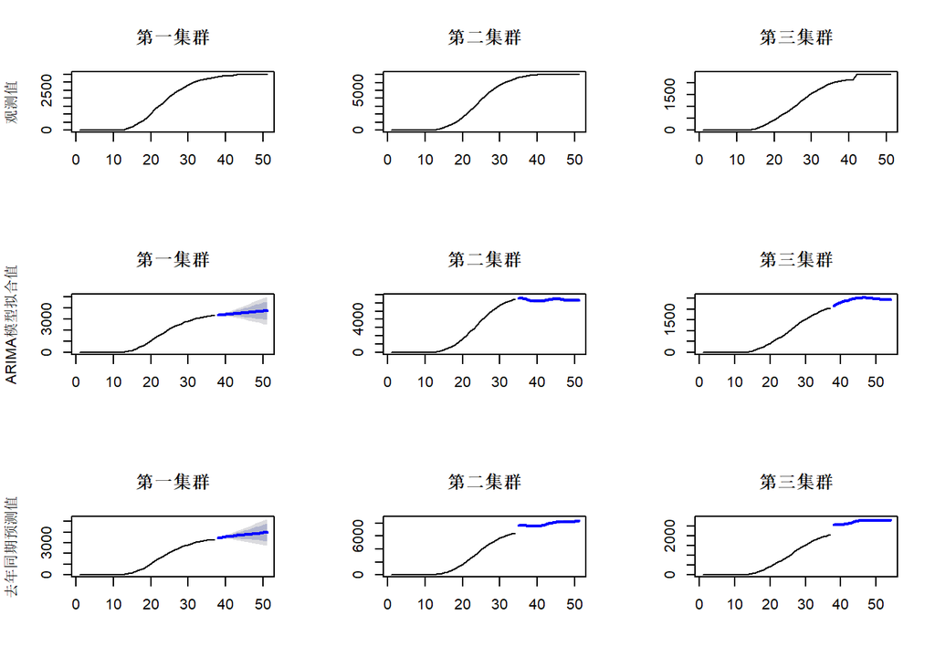

# 5 结论与不足

## 5.1 结论

自2020年1月10日起，武汉迁出客流量开始快速增长，而在1月23日实施封城令后，出境客流量急剧下降。截至1月23日，武汉q迁出人员中有71%前往湖北其他城市，29%迁移到其他省份。湖北省迁移数据与各省新冠疫情确诊人数呈现相似的波动格局，格兰杰因果检验发现人口迁移数据是各省疫情增长的原因之一。

我们研究了武汉迁入人口数的潜在影响因素。分析表明，武汉迁入人口数与距离武汉的距离呈负相关，相关系数-0.56(P=0.002)，与火车趟数、GDP和各省人口数呈现正相关，相关系数分别为0.86(P=29e-09),0.42(P=0.025),0.64(P=0.0003)。

每个省份集群的最优ARIMAX模型如上表所示。滞后1-10天的省份ARIMA(1,1,0)最优，滞后11-20和滞后20天以上的省份均为ARIMA(2,0,0)最优。运用去年农历同期数据估计,三集群省份武汉封城令可能分别减少465、1356和452人，一共会减少2273(95%；679，3869)例一代病例，在对新出现的传染病缺乏治疗和免疫的情况下，交通管控这种应急法被证明是一种有效的公共卫生干预措施。我们的研究结果为政府机构确定最佳的疾病控制策略和改善对未来突发公共卫生事件的准备提供了重要依据。

### 5.2 不足

本文研究也存在一定不足，首先，新冠疫情诊断能力和标准的变化可能导致改变了确诊人数的长期趋势。例如，在疫情爆发初期，新冠肺炎曾被误诊，后来由于诊断标准扩大，在2月13日左右病例激增，这可能在某种程度上扭曲了预测的准确性。其次，迁徙数据与疫情数据之间的时间相关性可能会被其他预防措施混淆，如加强自我隔离、广泛使用口罩和手部卫生处理。最后，本文分析的省份不包括西藏、青海和湖北，有一定局限性。